# **Princ. Biochemistry**

## *Prepared by [A. G. Hossion](https://www.researchgate.net/profile/Abu-Gafar-Hossion)*

## Unit I: Protein Structure and Function

## [**Lesson01 (ch1)**](https://drive.google.com/file/d/1-2SK6Oyvp2IS_EcSzYWmvREjuK7L0Ka-/view?usp=sharing)

## [*Amino ACIDS and the role of pH*](https://drive.google.com/file/d/1lv1YFYl-vCihKI9YIVB2d_RuEr0oV2WT/view?usp=sharing)

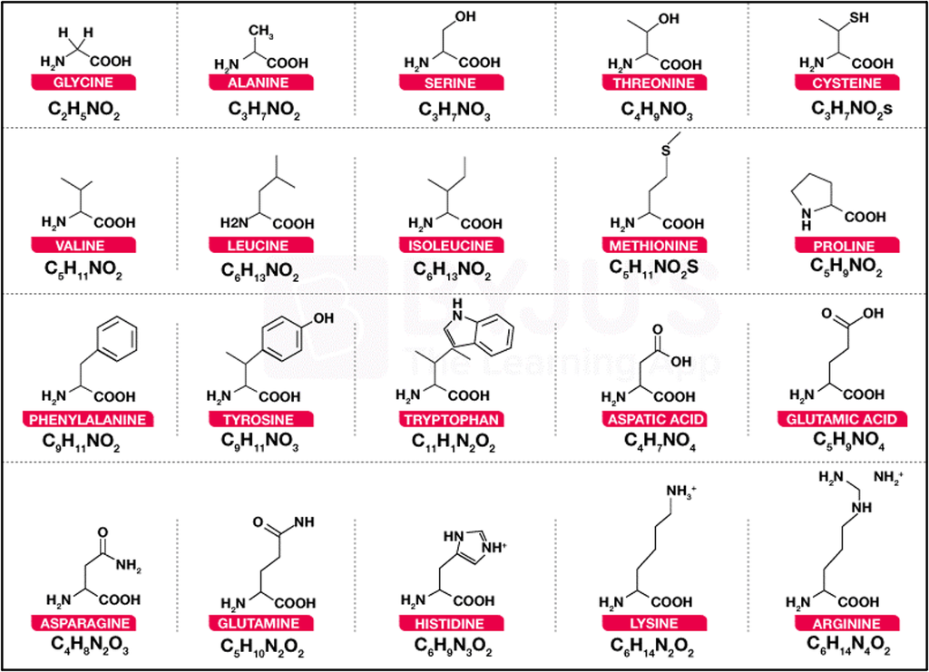

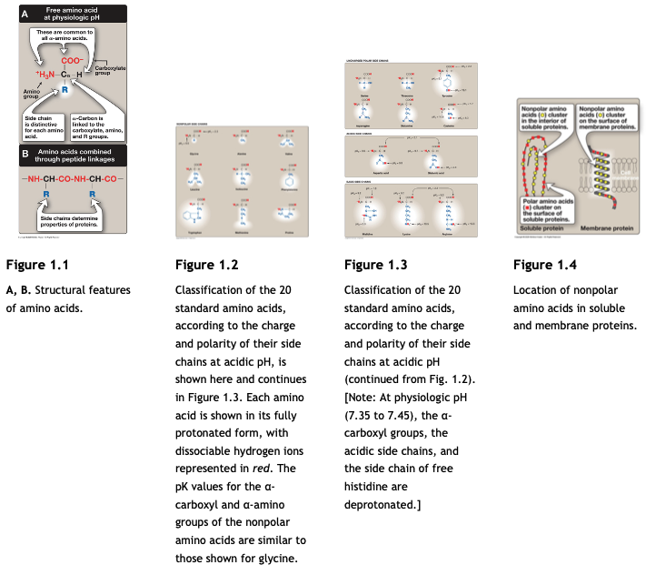

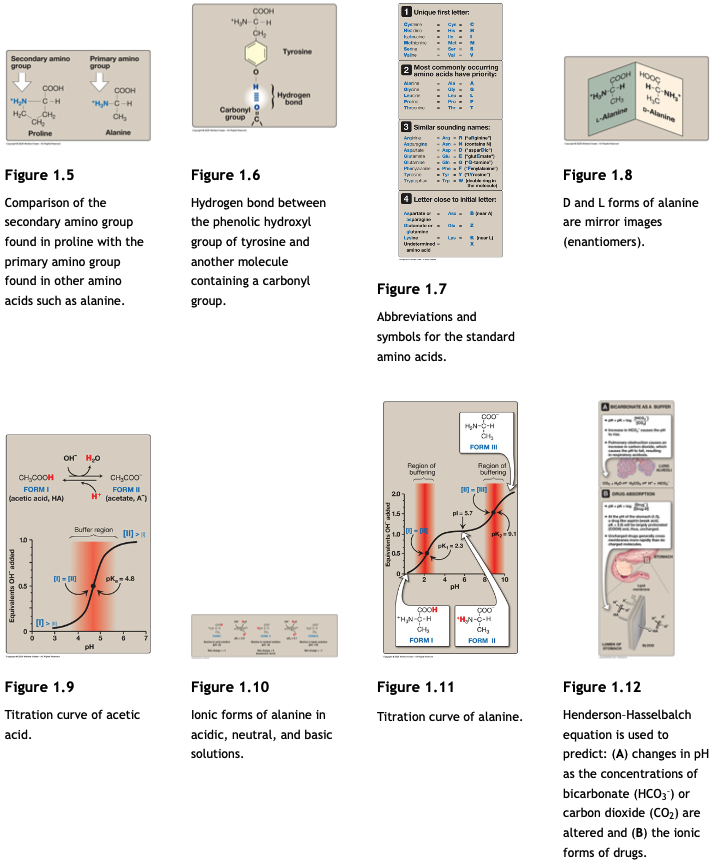

## **Concept Check and/or Mastering of the Modality**

- What is the isoelectric point of protein? what is the specific term that describes amino acids at this point? what is physiological pH?
- Classify all of the amino acids into the catagories charged, hydrophobic, hydrophilic, and aromatic.
- The peptide Val-Cys-Glu-Ser-Asp-Arg-Cys:

> (a) contains a side chain that can be phosphorylated (b) cannot move toward the cathod during electrophoresis at pH 5. (c) contains a side chain with a secondary amino group. (d) contains asparagin (e) cannot form internal disulfide bond.
- The titration curve for a nonpolar amino acid is shown below. Which of the following descriptions about the letters A through D is correct?

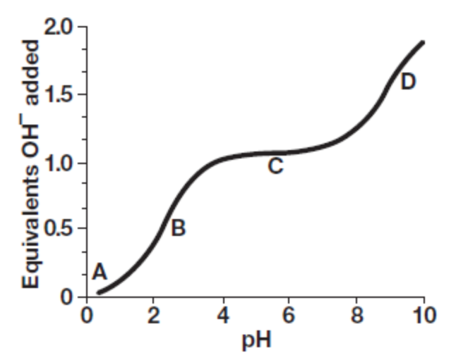

> (a) The amino acid could be lysine. (b) Point C represents the region where the net charge on the amino acid is zero. (c) Point B represents a region of minimal buffering. (d) Point D represents the pk of the amino acid's carboxyl group. (e) Point A represents the region where the amino acid is deprotonated.
- An amino acid that may have its side chain phosphorylated by the action of a kinase is:

> (a) Cys (b) Arg (c) Val (d) Gly (e) Ser
- An amino acid with a secondary amino group is geometrically incompatible with a right-handed spiral of an a helix; is observed to insert a kink in the amino acid chain and to interfere with the normally smooth, helical structure of the a helix; and is found in high concentration in collagen. The amino acid described is:

> (a) Gly (b) Cys (c) Pro (d) Ala (e) Ser
> - **Interactive** | [*Biochemical Protein & Amino Acid Analyzer*](https://protein-aa-pi-h8vfesshjecfebgxz8jybt.streamlit.app/)

## **[Lesson-02(ch2)](https://drive.google.com/file/d/1VNZx01D-GVg6gq0WLVbWYFrcIAi_t__p/view?usp=sharing)**

## [*Protein Structure*](https://drive.google.com/file/d/1mUknqIn3x4PZac4umJAiJSSAuGQeKFlY/view?usp=drive_link)

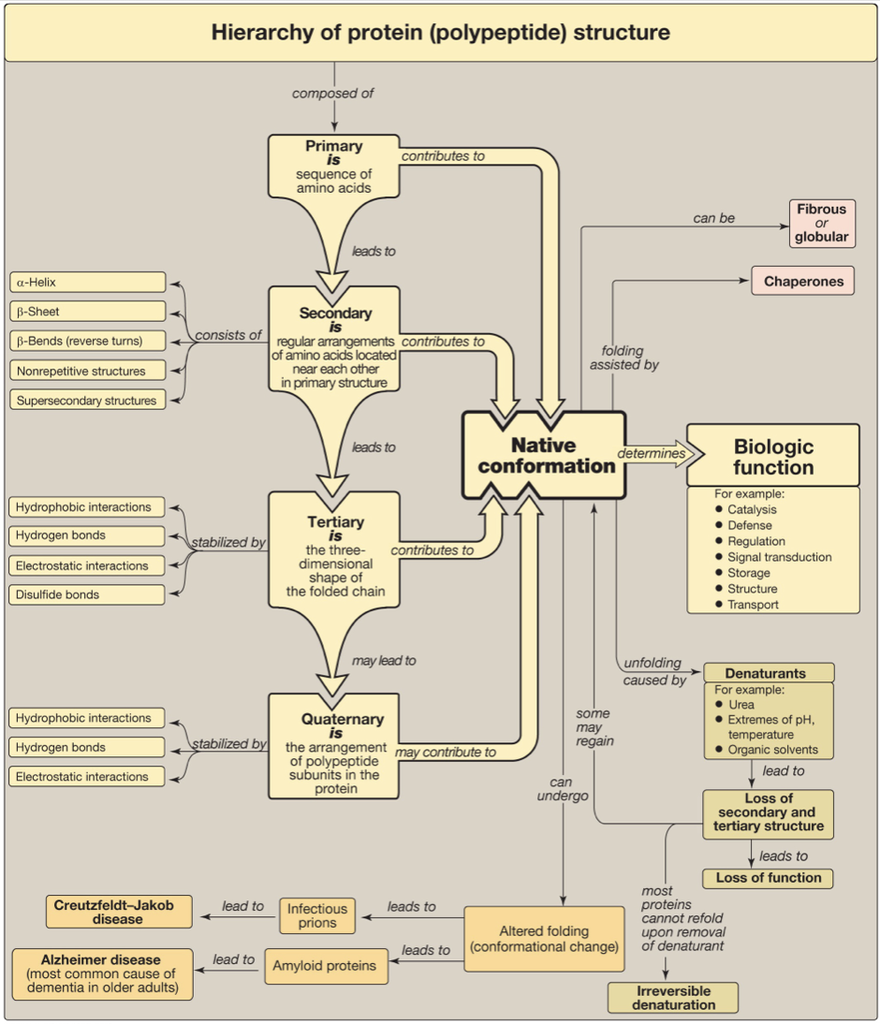

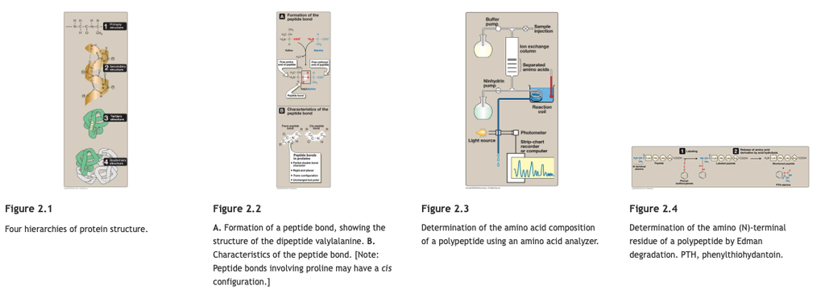

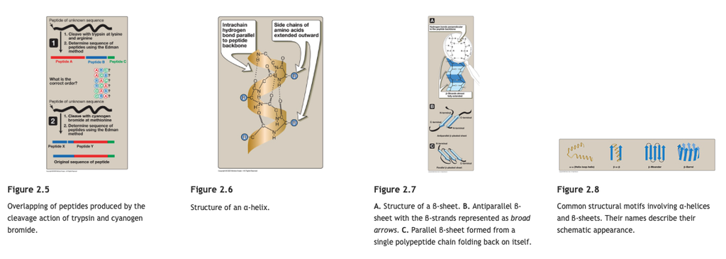

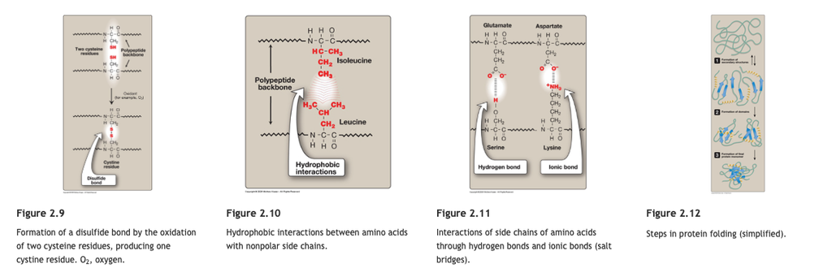

## **Concept Check and/or Mastering of the Modality**

- What is pepetide/amide bond and how is it formed?
- Explain the physical relevance of the Phi and Psi angles.
- Name and briefly describe the four levels of protein structure.
- Explain how an alpha helix can be amphipathic.
- Explain why secondary structure are so prevalent in proteins.
- What are the three most common amino acids found in alpha helices, beta strands and beta turns, respectively?
- What are the three ways in which quaternary structure can provide increased functionality for a protein?
- How does the amino acids sequence of a protein determine its chemical properties and function?
- Which statement is true of beta-sheets only, and not alpha-helices?

> (a) They may be found in supersecondary structures. (b) They are stabilized by interchain hydrogen bonds. (c) They are examples of secondary structure. (d) They may be found in typical globular proteins.
- A particular point mutation results in disruption of the a-helical structure in a segment of the resulting abnormal protein. The most likely change in the primary structure of the mutant protein IS:

> (a) lysine to arginine (b) glutamate to aspartate (c) methionine to proline (d)valine to alanine.
- Quaternary structure of a protein refers to:

  > (a) local arrangements of amino acids including a helices and sheets (b) the linear order of amino acids as encoded by DNA and translated from mRNA (c) folding into subunits driven by the way the R groups interact (d) multiple protein subunits, properly folded, assembled together.
- Adjacent amino acids in a polypeptide are joined together by peptide bonds that involve a/an:

  > (a) R group and amino group (b) carboxyl group and amino group (c) carboxyl group and R group (d) carboxyl group and hydrogen atom.
- Stability of tertiary protein structure is provided in part by:

  > (a) B meanders. (b) a helices. (c) disulfide bond formation. (d)aminopeptidases.
- When considering protein structure, which of the following statements is true?

  > (a) Denaturation of proteins leads to irreversible loss of secondary structural elements. (b) The primary driving force for protein folding is the hydrophobic effect. (c) Proteins with one polypeptide have quaternary structure stabilized by covalent bonds. (d) Peptide bonds that link amino acids most commonly occur in the cis configuration. (e) Disulfide bonds in proteins are between cysteine residues adjacent in the primary structure.
> - **Interactive** | [*Ramachandran model*](https://ramachandran-71zn.onrender.com) | [Ramachandran Plot Simulator](https://phi-psi-ev6frtum2zfjjqjiaa3h8t.streamlit.app/)

## **Lesson-03(ch-03/04)**

## [*Protein Folding and Denaturation*](https://drive.google.com/file/d/1IQLG_Ft6VHx0n1KUengwaOWFwL5hAPgt/view?usp=sharing)

#### [Globular Protein](https://drive.google.com/file/d/1k1le-Ip6d1DE7SjVF2TPtTa2TlEFb8UT/view?usp=sharing) and [Fibrous protein](https://drive.google.com/file/d/1E0RO6QJnPXWpLv4QTMNc_Ay6KjnB9qwe/view?usp=sharing).

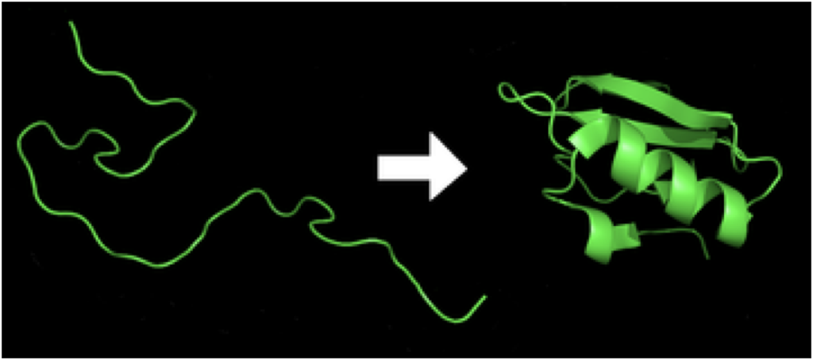

#### **ch-03_Globular protein** Hemoglobin

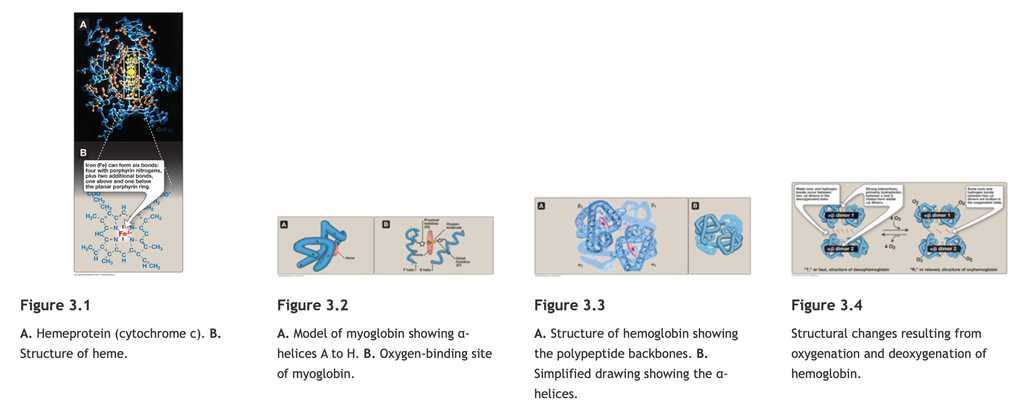

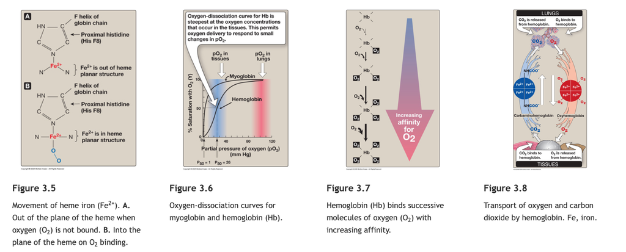

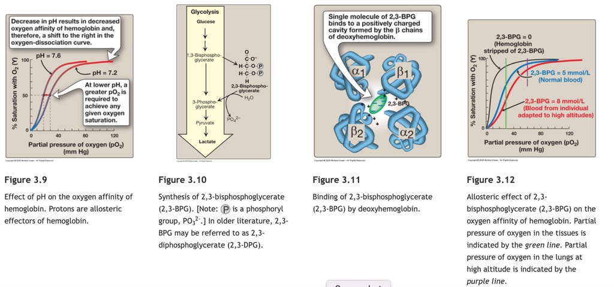

#### **ch-04_Fibrous protein** Collagen

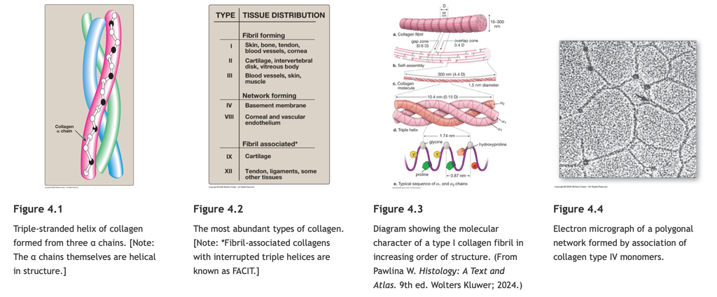

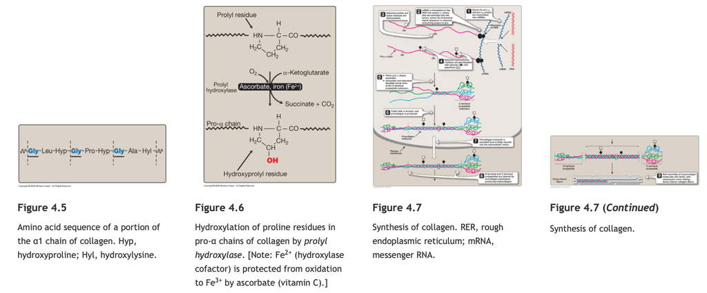

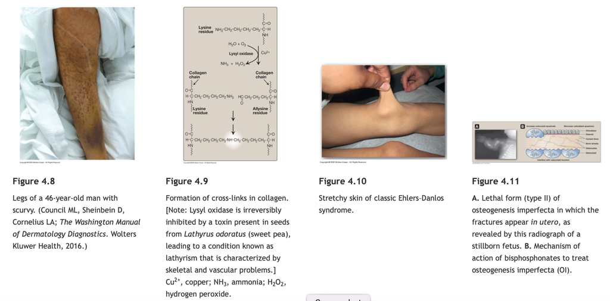

## **Concept Check and/or Mastering of the Modality**

- Explain how the pKa of an amino acids can differ within a folded protein compared to that of the free amino acid in water?
- What is thought to be the dominat mechanisms of protein folding? Why can it not be random?
- What are the enthalpic and entropic factors that lead to the stabilization of protein upon protein folding?
- What are the two phenotypic consequences produced by protein folding diseases?
- What are protein folds and how do they relate to protein function.
- If the entropy of the polypepetide chain is reduced when going from the unfolded state to the folded state of a protein. how does protein folding occor if this is entropically unfavrrable?
- Explain two key factors affecting protein denaturation?
- Which one of the following statements concerning different forms of hemoglobin is correct?

> (a) Fetal blood has a lower affinity for oxygen than does adult blood because HbF has an increased affinity for 2,3-bisphosphoglycerate. (b) The globin chain composition of HbF is a282. (c) HbA, appears early in fetal life. (d) HbA1 differs from HA by a single, genetically determined amino acid substitution. (e) HbA is the most abundant hemoglobin in normal adults.
- Which one of the following statements concerning the binding of oxygen by hemoglobin is correct?

> (a) The oxygen affinity of hemoglobin increases as the percentage saturation increases. b) (b) oxyhemoglobin and deoxyhemoglobin have the same affinity for protons. c) The Bohr effect results in a lower oxygen affinity at higher pH values. d) The hemoglobin tetramer binds four molecules of 2,3-bisphosphoglycerate. (e) Carbon dioxide increases oxygen affinity of hemoglobin.
- In a patient with an NADH-cytochrome bs reductase deficiency, which one of the following would most likely be increased?

> (a) HbF (b) Fe<sup>3+</sup> (c) HbA2 (d) 2.3-BPG (e) HDS
- A 30-year-old patient presents with hearing loss and hypertension. Analysis of his urine indicates proteinuria. He is found to have a defect in type IV collagen. Which of the following is the most likely diagnosis in this patient?

> (a) Marfan syndrome (b) Alport syndrome (c) Osteogenesis imperfecta (d) Ehlers-Danlos syndrome (e) Menes syndrome
> - **Interactive** | [*Protein Folding Simulator*](https://globularproteinfolding-r3txctlxqeejs3pyxhihcw.streamlit.app/)

## UNIT VII Storage and Expression of Genetic Information

## **Lesson04 (ch-30)**

### [*DNA Structure, Replication and Repair*](https://drive.google.com/file/d/1GdlLXmqO0s49yDRmarDWV3EGa5qUPbLt/view?usp=sharing)

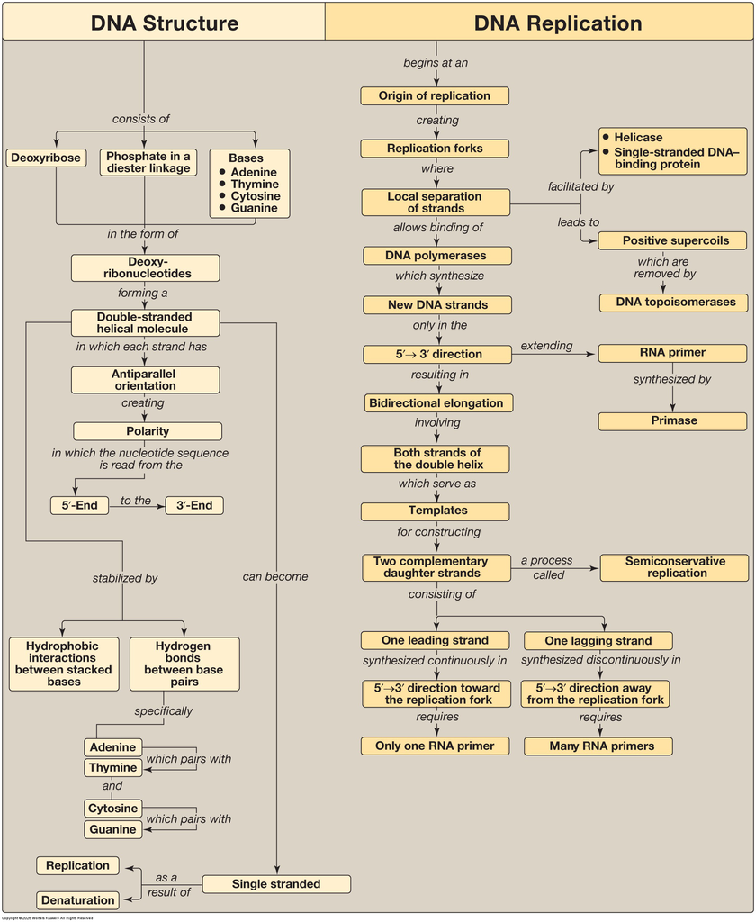

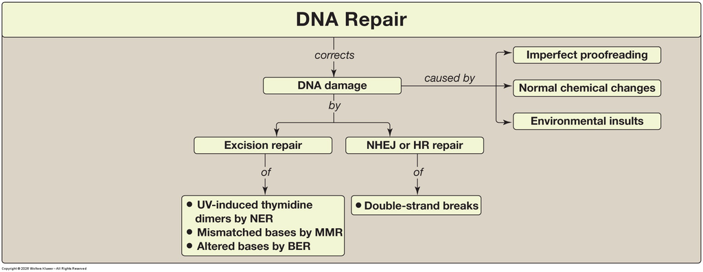

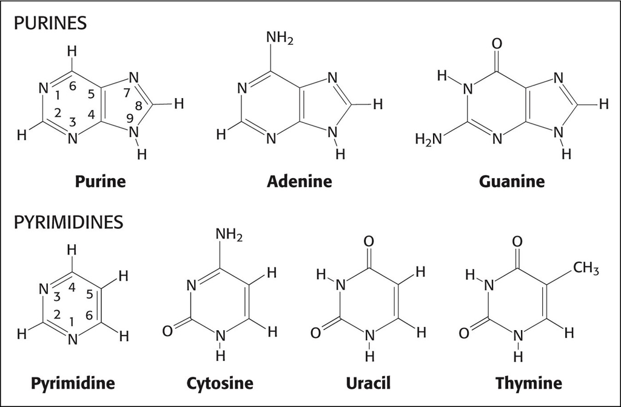

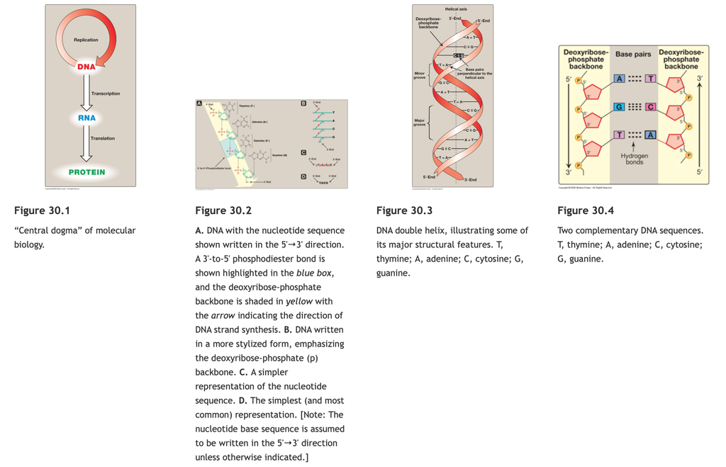

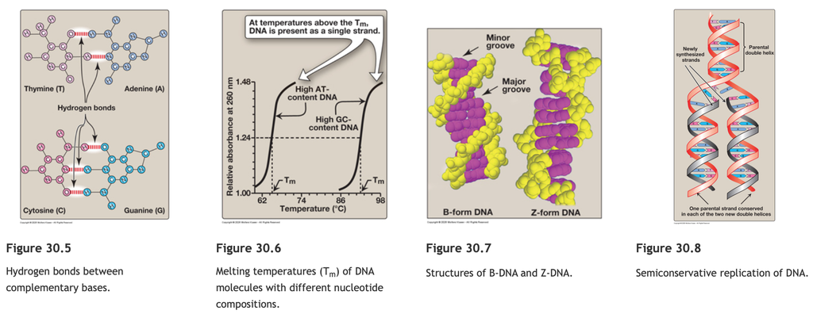

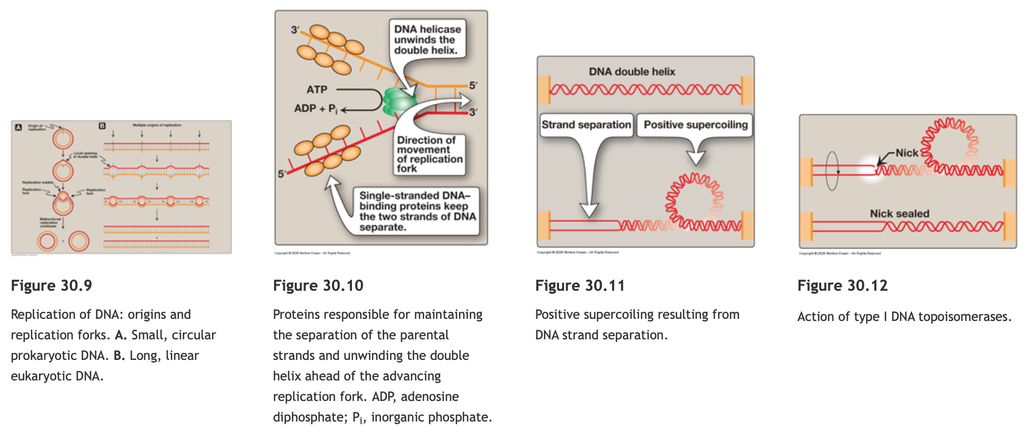

## **Concept Check and/or Mastering of the Modality**

[Animation DNA Synthesis overview](https://thepoint.lww.com/MedEdStandardJWPlayer/Show?assetInstanceId=1123436)  
[Animation DNA Synthesis detail](https://thepoint.lww.com/MedEdStandardJWPlayer/Show?assetInstanceId=1123437)  
[Animation DNA repair](https://thepoint.lww.com/MedEdStandardJWPlayer/Show?assetInstanceId=1123438)

- What is the mean by semiconservative replication? How is the difference from conservative or dispersive replication?
- What are Okazaki fragments?
- What is the nucleophile in the reaction catalyzed by DNA polymerase? What is the significance of this in terms of initiating DNA synthesis?
- What is the primary replicative polymerase in prokaryotic and eukaryotic cells?
- Describe the typical major elements of a replication fork?
- What are the major events that occur at oriC to allow initiation of DNA synthesis?
- What is unique about the structure of telomerase that allows it to extend the end of chromosomes?
- Describe Ames test and explain its importance.
- What happen during cytosine deamination, and how is it repaired?
- If unpaired, what effect can cyclobutene pyrimidine dimers have an cellular processes?
- Show the product of O6 -methylation of guanine, and explain how it is repaired?
- What are the two roles of methylation by Dam methylase-one in the replication process, the other in repair?
- what are the major differences between meiotic homologous recombination by double-strand break and homologous recombination for the repair of double strands break caused by DNA damaging events?
- While studying the structure of a small gene that was sequenced during the Human Genome Project, an investigator notices that one strand of the DNA molecule contains 20 A, 25 G, 30 C, and 22 T. How many of each base is found in the complete double-stranded molecule?

> (a) A =50, G = 47, C = 50, T = 47  
> (b) ( A = 40, G = 50, C = 60, T = 44  
> (C) A = 42, G = 55, C = 55, T = 42  
> (D) A = 44, G = 60, C = 50, T = 40  
> (E) A = 45. G= 45. C= 52. T = 52
- List the order in which the following enzymes participate in leading strand synthesis during prokaryotic replication 1 to 6.

> Primase  
> Polymerase I (5' >3' exonuclease activity)  
> Ligase  
> Polymerase Ill  
> Polymerase I (3' >5' exonuclease activity)  
> Polymerase I (5' >3' polymerase activity)
- A 10-year-old female is brought by her parents to the dermatologist. She has many freckles on her face, neck, arms, and hands, and the parents report that she is unusually sensitive to sunlight. Two basal cell carcinomas are identified on her face. Which of the following processes is most likely to be defective in this patient?

> (a) Removal of incorrectly paired nucleotides by Pol & 3' >5' exonuclease activity  
> (b) Removal of uracil from DNA by base excision repair  
> (c) Removal of mismatched bases from the 3' end of Okazaki fragments by a methyl-directed process  
> (d) Repair of double-strand breaks by error-prone homologous recombination  
> (e) Removal of pyrimidine dimers from DNA by nucleotide excision repair
- Based on the following 5' 3' strand sequences, which DNA fragment will denature at the lowest temperature if all fragments are in solution at the same pH?

> (a) AAGTTTGCAATA  
> (b) AGGGCTCCAATA  
> (c) AGGACTCCAATA  
> (d) AGGCCTCCAATA  
> (e) ACGACTCCCATA
- Telomeres are complexes of DNA and protein that protect the ends of linear chromosomes. In most normal human somatic cells, telomeres shorten with each division. In stem cells and cancer cells, however, telomeric length is maintained. In the synthesis of telomeres: telomerase, a ribonucleoprotein, provides both the RNA and the protein needed for synthesis.

> (a) the shorter -rich strand gets extended.  
> (b) the direction of synthesis is 3'>5'.  
> (c) the RNA of telomerase is a ribozyme.  
> (d) the protein of telomerase is a DNA-directed DNA polymerase.  
> (e) the RNA of telomerase serves as a primer.
- In human cells, DNA wraps around and binds to histone proteins to form nucleosomes. What property of the histone proteins allows them to bind tightly to DNA?

> (a) Positive charges on amino acids  
> (b) Intercalation of aromatic amino acids into the DNA helix  
> (c) Endonuclease activity and covalent bonding with end of a DNA strand  
> (d) Methyl groups that create hydrophobic interactions  
> (e) Spherical tertiary structure
> - **Interactive** | [*DNA Replication-Translation-Repair Simulation*](https://dnastrureplirep-lgsnmfnmhlhwqjceuapefu.streamlit.app/) | [DNA replication fork-lagging strand engine](https://dna-replication-fork.onrender.com)
> - **Interactive** | [*DNA Repair & Synthesis Workbench*](https://dna-stru-repli-rep.onrender.com) | [DNA_ber](https://dna-ber.onrender.com) | [DNA_ner_mmr](https://dna-ner-mmr.onrender.com)| [DNA_dsbr](https://dna-ner-mis-doubles.onrender.com)

## **Lesson05 (ch-31)**

### [*RNA Structure, Synthesis and Processing*](https://drive.google.com/file/d/1zZcr0Ez9Khh_PccuPFkphXEM3B3SwNNQ/view?usp=sharing)

[figure not shown]

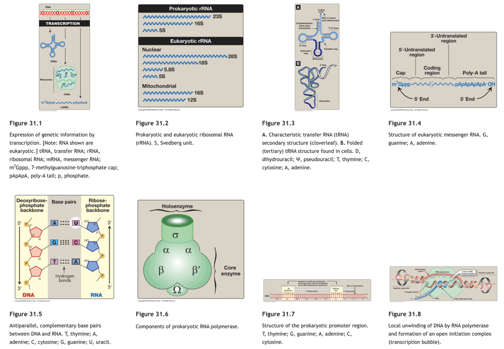

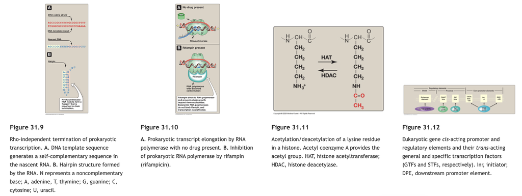

## **Concept Check and/or Mastering of the Modality**

[Animation Protein Synthesis details](https://thepoint.lww.com/MedEdStandardJWPlayer/Show?assetInstanceId=1123439)  
[Animation Protein Synthesis overview](https://thepoint.lww.com/MedEdStandardJWPlayer/Show?assetInstanceId=1123440)

- A scientist growing yeast cell cultures suspects that the cultures are contaminated with bacteria. Which of the following rRNA species could they detect in the culture to confirm that bacteria are present?

> (a) 23S rRNA (b) 125 rRNA (c) 16S rRNA (d) 285 rRNA (e) 5S rRNA
- Which of the following protein factors identifies the promoter of protein-coding genes in eukaryotes?

> (a) U1 (b) Sigma (c) Rho (d) TFIID (e) Pribnow box
- A mutation to which of the following sequences in eukaryotic messenger RNA (mRNA) would most likely affect the process by which the 3'-end polyadenylate (poly-A) tail is added to the mRNA?

> (a) TATAAA (b) CAAT (c) GU... A ... AG (d) AAUAAA (e) CCA
- A 4-year-old child who easily tires and has trouble walking is diagnosed with Duchenne muscular dystrophy, an X-linked recessive disorder. Genetic analysis shows that the patient's gene for the muscle protein dystrophin contains a mutation in its promoter region. Of the choices listed, which of the following would be the most likely to be defective due to this mutation?

> (a) Splicing of dystrophin messenger RNA (b) Initiation of dystrophin transcription (c) Termination of dystrophin transcription (d) Tailing of dystrophin messenger RNA (e) Capping of dystrophin messenger RNA
- What is the sequence (conventionally written) of the RNA product of the DNA template sequence, GATTAC, also conventionally written?
- An 8-month-old male with severe anemia is found to have ß-thalassemia. Genetic analysis shows that one of his ß-globin genes has a mutation that creates a new splice acceptor site 19 nucleotides upstream of the normal splice acceptor site of the first intron. Which of the following best describes the new messenger RNA molecule that can be produced from this mutant gene?

> (a) Exon 2 will be too short. (b) Exon 2 will be missing. (c) Exon 1 will be too long. (d) Exon 2 will be too long. (e) Exon 1 will be too short.
- A small RNA species is isolated from a eukaryotic cell. The RNA has an amino acid covalently linked to its 3'-end. Which of the following would be a posttranscriptional modification also found in this RNA species?

> (a) Pyrimidine dimers (b) Xanthine (c) 7-Methylguanosine (d) Apurinic sites (e) Dihydrouracil